# Stat517_project_2

Abhinav

September 29, 2018

```r
library(tidyverse)
```

```r
library(dendroextras)
library(dendextend)
library(cluster)
library(circlize)
library(mclust)
library(factoextra)
library(MVA)
library(NbClust)
library(seriation)
```

For the year 2015

```r
happy1 = read.csv("https://raw.githubusercontent.com/sauchilee/Stat517/master/Data/World_Happiness_2015.csv")
dim(happy1)
```

```
## [1] 158  12
```

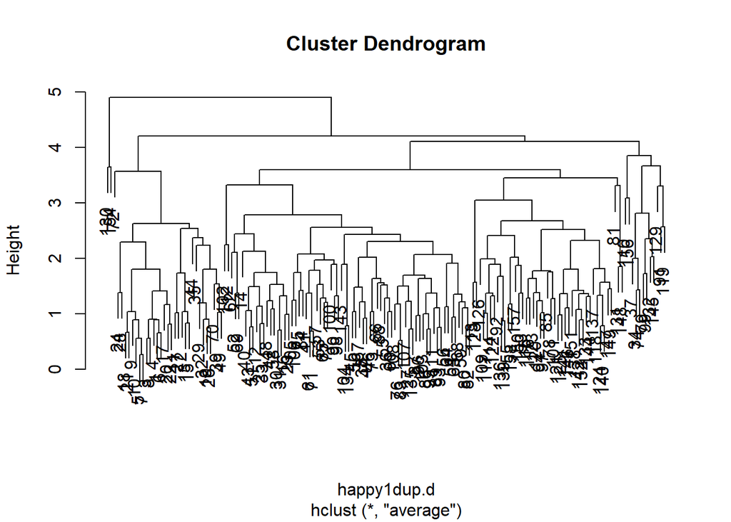

```r
happy1dup<-happy1[,c(2,6:12)]
happy1dup.s = scale(happy1dup[,-1])
#happy1.s
happy1dup.d = dist(happy1dup.s)
#happy1.d
happy1dup.hc.s = hclust(happy1dup.d,method="average")
plot(happy1dup.hc.s)
```

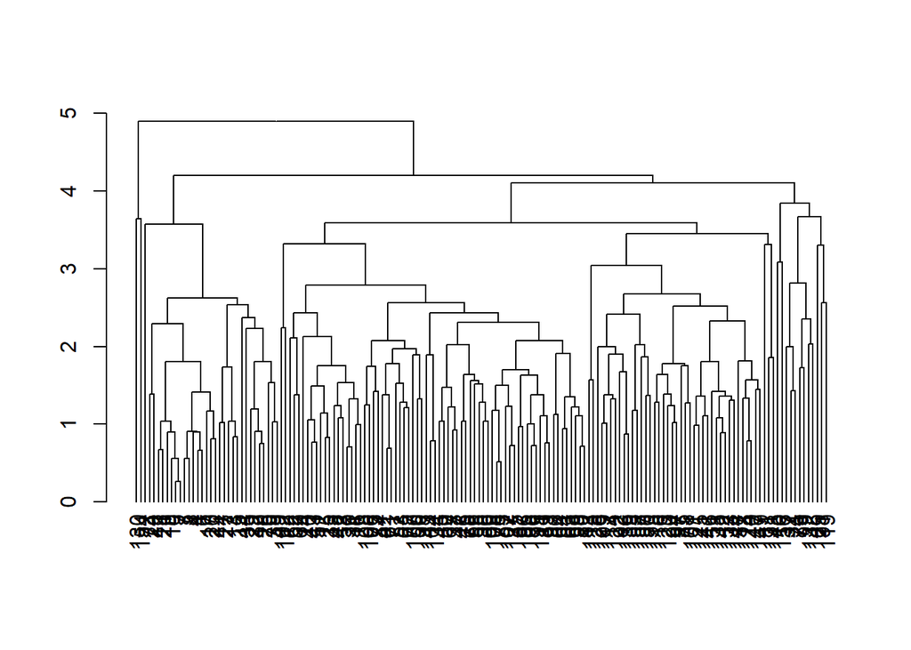

```r
dend=as.dendrogram(happy1dup.hc.s)
#labels_colors(dend)=as.numeric(as.factor(happy1dup$Region[happy1dup.hc.s$order]))
plot(dend)
```

Partition Clustering

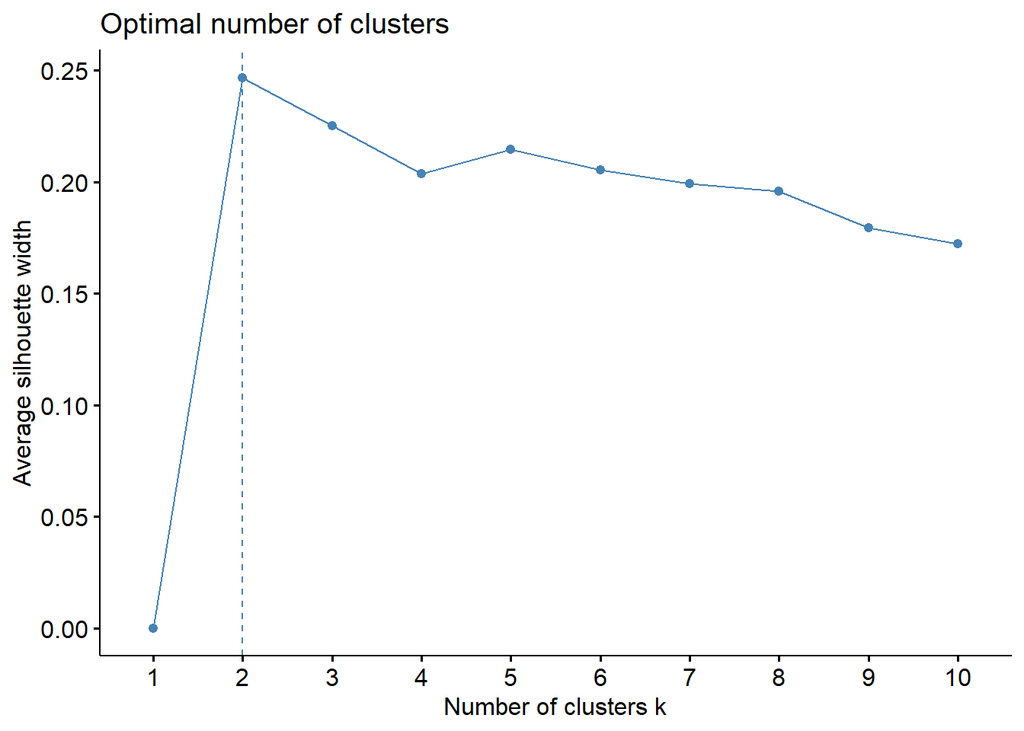

```r
set.seed(150)
fviz_nbclust(happy1dup.s,kmeans,method="silhouette")
```

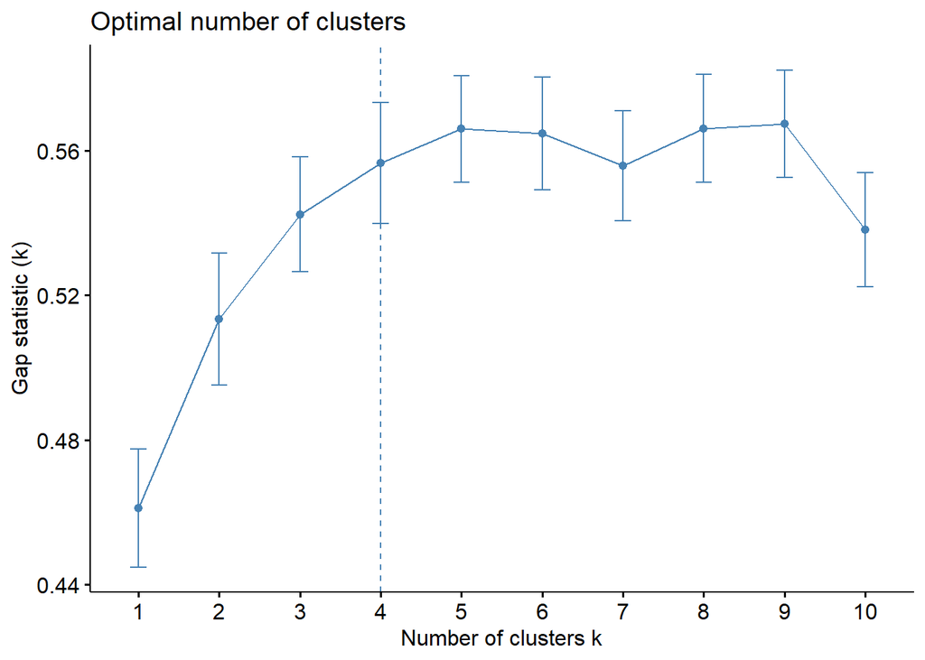

```r
fviz_nbclust(happy1dup.s,kmeans,method="gap_stat")
```

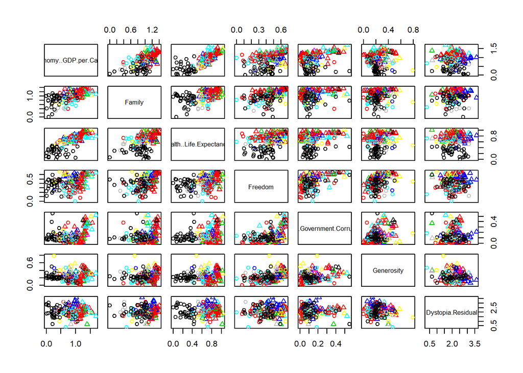

```r
happy1dup.k2<-kmeans(happy1dup.s,centers = 2,iter.max=100,nstart=25)
happy1dup.k4<-kmeans(happy1dup.s,centers = 4,iter.max=100,nstart=25)
pairs(happy1dup[-1],pch=happy1dup.k2$cluster,col=unclass(happy1dup[,1]))
```

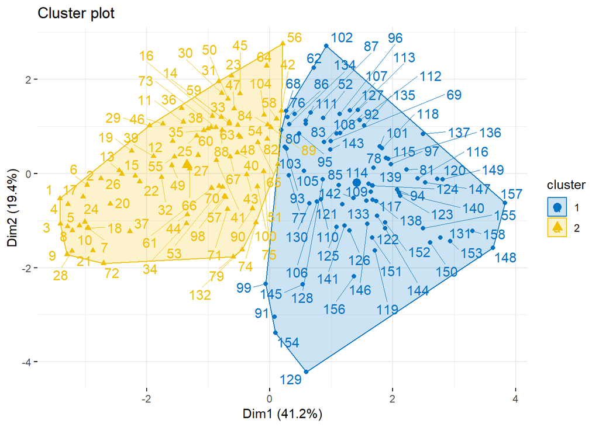

```r
fviz_cluster(happy1dup.k2,data=happy1dup.s,ellipse.type ="convex",palette="jco",repel = TRUE, ggtheme = theme_minimal())
```

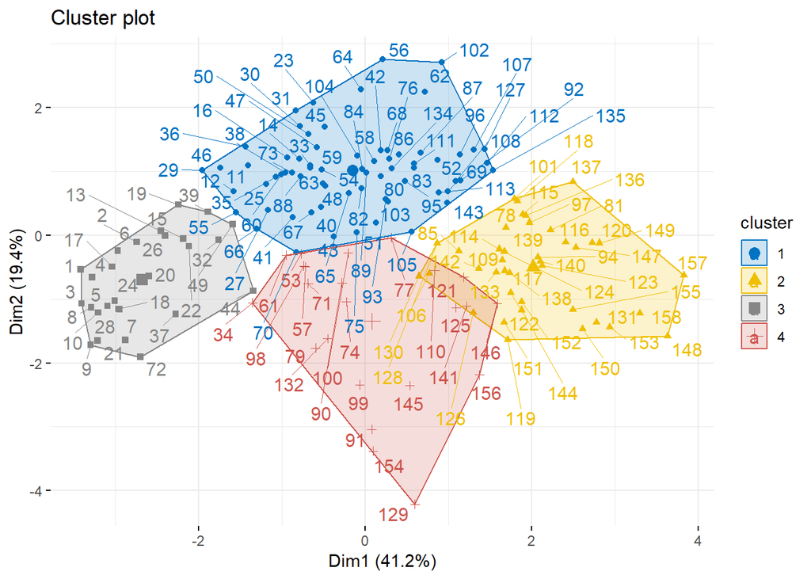

```r
fviz_cluster(happy1dup.k4,data=happy1dup.s,ellipse.type ="convex",palette="jco",repel = TRUE, ggtheme = theme_minimal())
```

M Clust:

```r
happy1dup.mclust<-Mclust(happy1dup.s)
summary(happy1dup.mclust)
```

```
## ----------------------------------------------------
## Gaussian finite mixture model fitted by EM algorithm
## ----------------------------------------------------
##
## Mclust VVE (ellipsoidal, equal orientation) model with 4 components:
##
##  log.likelihood   n df       BIC       ICL
##       -1179.659 158 80 -2764.326 -2776.977
##
## Clustering table:
##  1  2  3  4
## 19 34 65 40
```

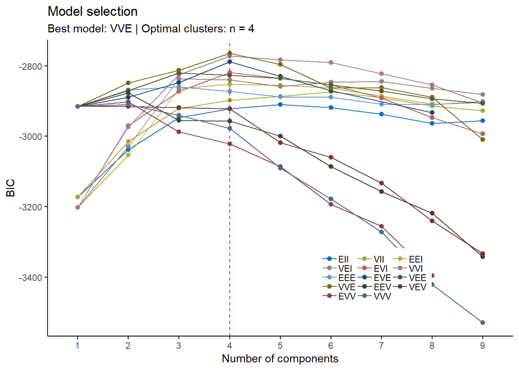

```r
fviz_mclust(happy1dup.mclust,"BIC",palette="jco")
```

For the year 2016

```r
happy2=read.csv("https://raw.githubusercontent.com/sauchilee/Stat517/master/Data/World_Happiness_2016.csv")
dim(happy2)
```

```
## [1] 157  13
```

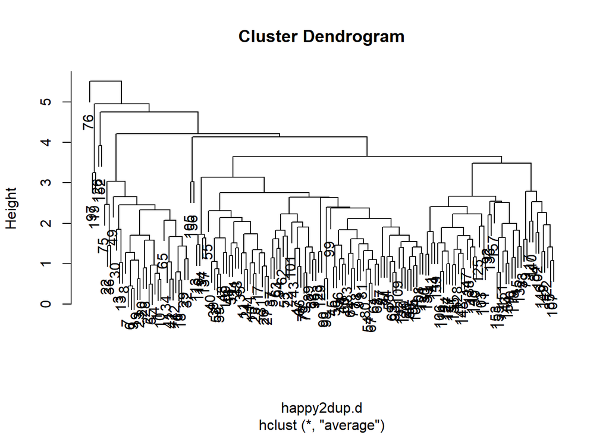

```r
happy2dup<-happy2[,c(2,7:13)]
happy2dup.s = scale(happy2dup[,-1])
#happy1.s
happy2dup.d = dist(happy2dup.s)
#happy1.d
happy2dup.hc.s = hclust(happy2dup.d,method="average")
plot(happy2dup.hc.s)
```

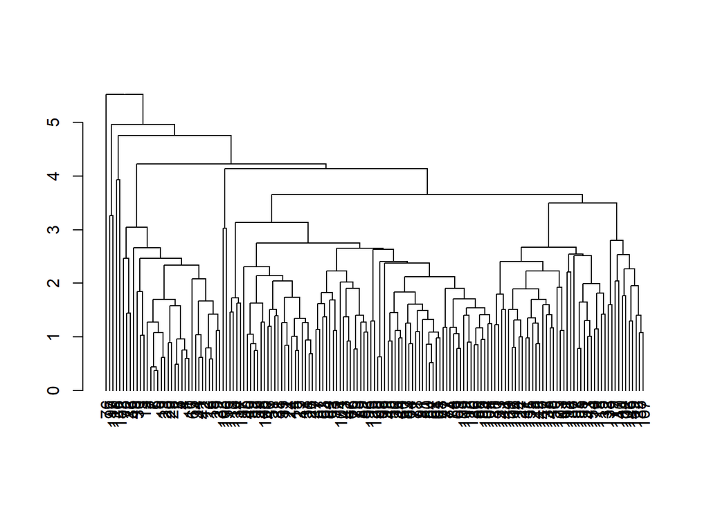

```r
dend=as.dendrogram(happy2dup.hc.s)
#labels_colors(dend)=as.numeric(as.factor(happy2dup$Region[happy2dup.hc.s$order]))
plot(dend)
```

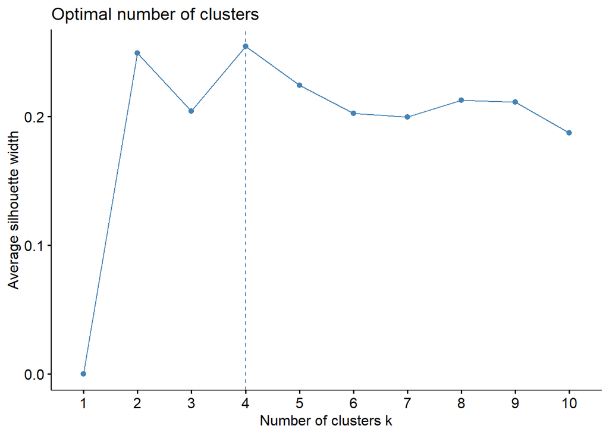

```r
set.seed(150)
fviz_nbclust(happy2dup.s,kmeans,method="silhouette")
```

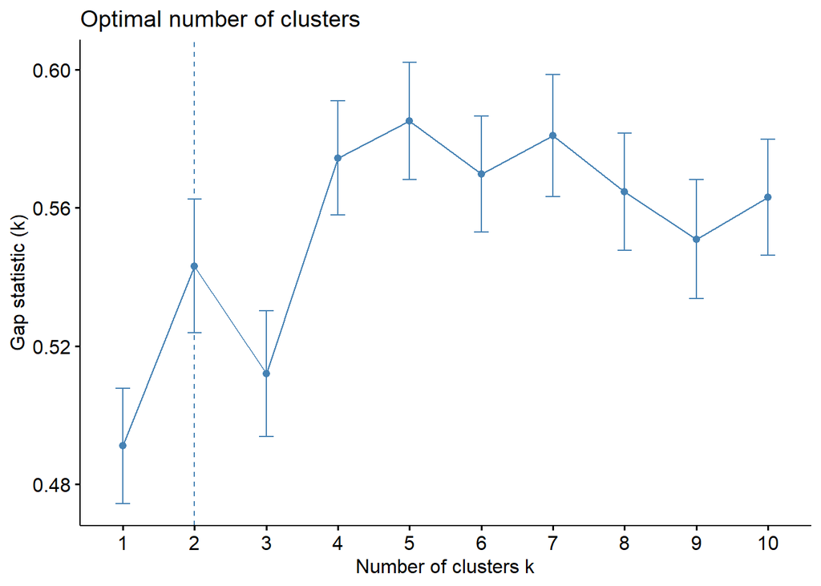

```r
fviz_nbclust(happy2dup.s,kmeans,method="gap_stat")
```

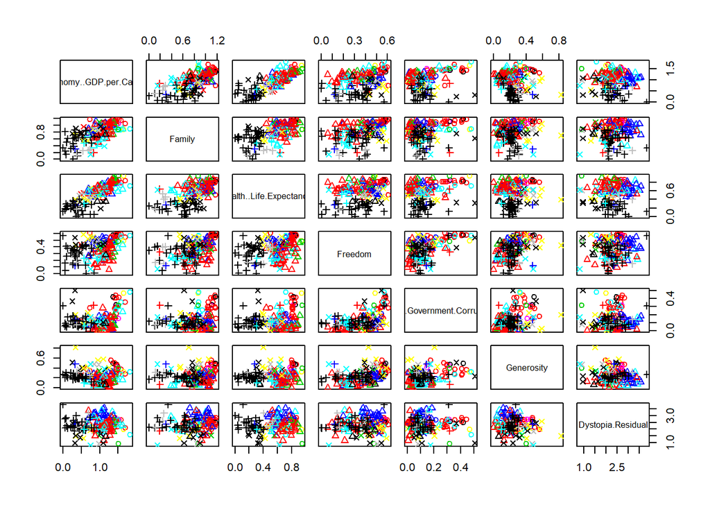

```r
happy2dup.k2<-kmeans(happy2dup.s,centers = 4,iter.max=100,nstart=25)
happy2dup.k4<-kmeans(happy2dup.s,centers = 2,iter.max=100,nstart=25)
pairs(happy2dup[-1],pch=happy2dup.k2$cluster,col=unclass(happy2dup[,1]))
```

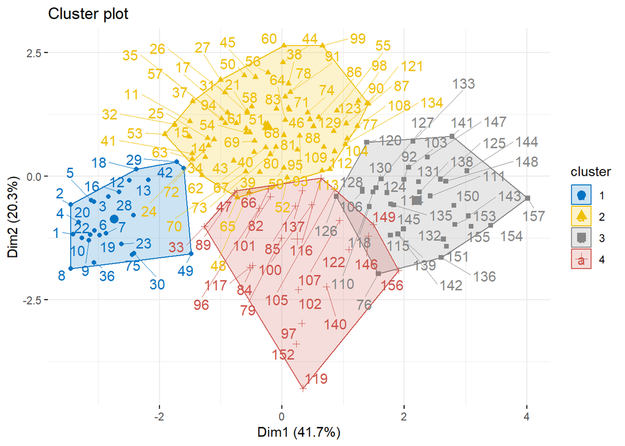

```r
fviz_cluster(happy2dup.k2,data=happy2dup.s,ellipse.type ="convex",palette="jco",repel = TRUE, ggtheme = theme_minimal())
```

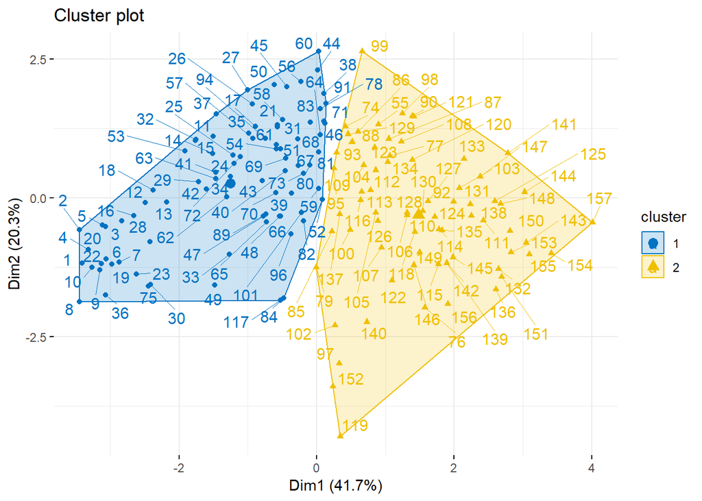

```r
fviz_cluster(happy2dup.k4,data=happy2dup.s,ellipse.type ="convex",palette="jco",repel = TRUE, ggtheme = theme_minimal())
```

M Clust:

```r
happy2dup.mclust<-Mclust(happy2dup.s)
summary(happy2dup.mclust)
```

```
## ----------------------------------------------------
## Gaussian finite mixture model fitted by EM algorithm
## ----------------------------------------------------
##
## Mclust VVI (diagonal, varying volume and shape) model with 5 components:
##
##  log.likelihood   n df       BIC       ICL
##       -1196.092 157 74 -2766.347 -2779.408
##
## Clustering table:
##  1  2  3  4  5
## 18 17 51 33 38
```

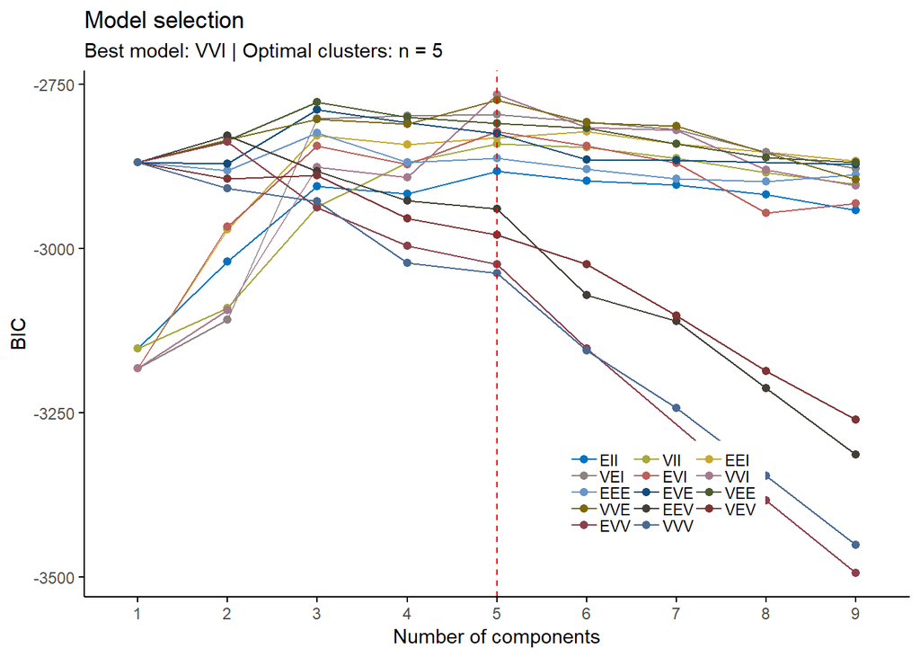

```r
fviz_mclust(happy2dup.mclust,"BIC",palette="jco")
```

For the year 2017

```r
happy3=read.csv("https://raw.githubusercontent.com/sauchilee/Stat517/master/Data/World_Happiness_2017.csv")
dim(happy3)
```

```
## [1] 155  12
```

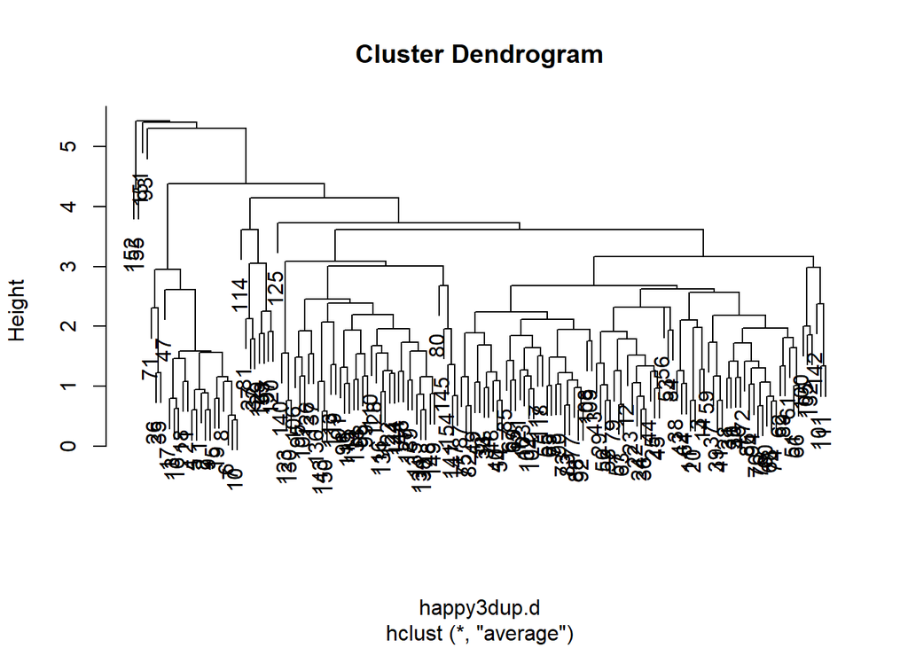

```r
happy3dup<-happy3[,c(2,6:12)]
happy3dup.s = scale(happy3dup[,-1])
#happy1.s
happy3dup.d = dist(happy3dup.s)
#happy1.d
happy3dup.hc.s = hclust(happy3dup.d,method="average")
plot(happy3dup.hc.s)
```

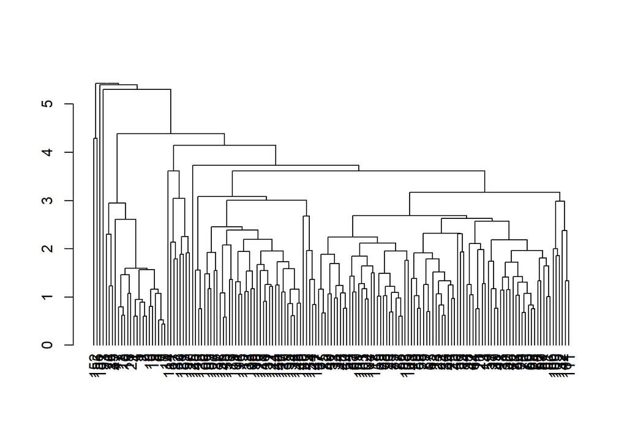

```r
dend=as.dendrogram(happy3dup.hc.s)
#labels_colors(dend)=as.numeric(as.factor(happy2dup$Region[happy2dup.hc.s$order]))
plot(dend)
```

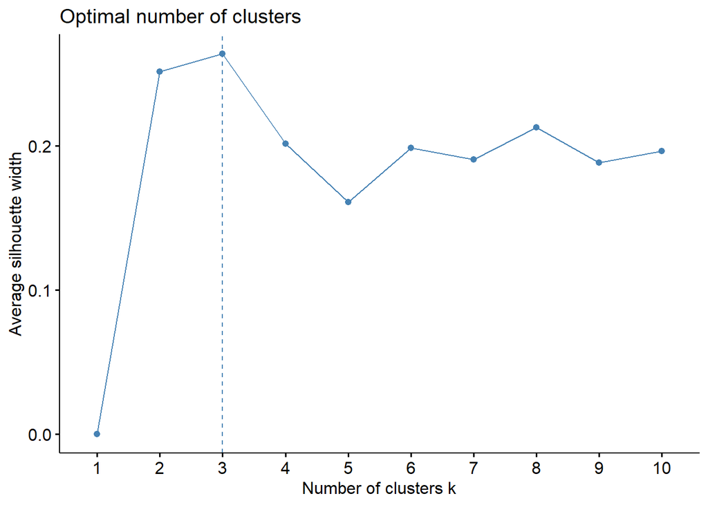

```r
set.seed(150)
fviz_nbclust(happy3dup.s,kmeans,method="silhouette")
```

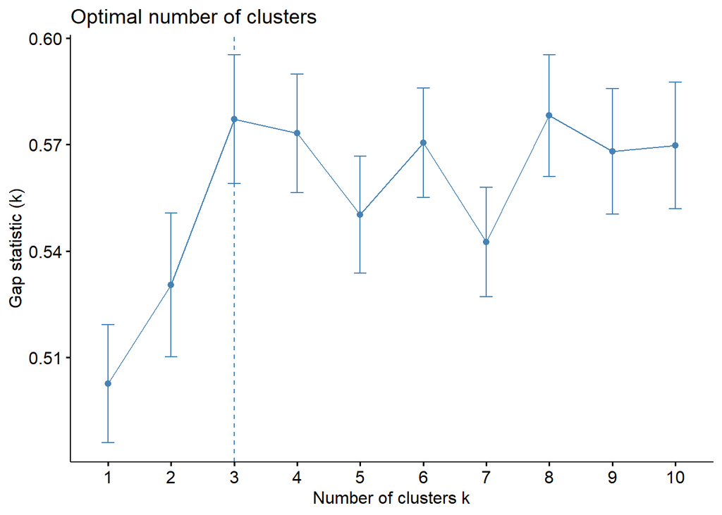

```r
fviz_nbclust(happy3dup.s,kmeans,method="gap_stat")
```

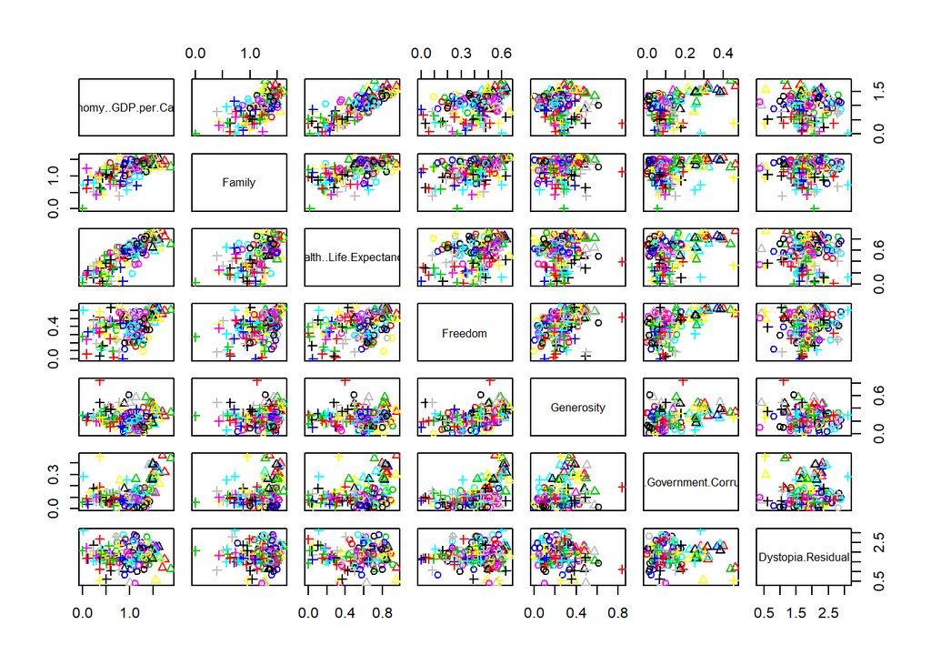

```r
happy3dup.k2<-kmeans(happy3dup.s,centers = 3,iter.max=100,nstart=25)
happy3dup.k4<-kmeans(happy3dup.s,centers = 3,iter.max=100,nstart=25)
pairs(happy3dup[-1],pch=happy3dup.k2$cluster,col=unclass(happy3dup[,1]))
```

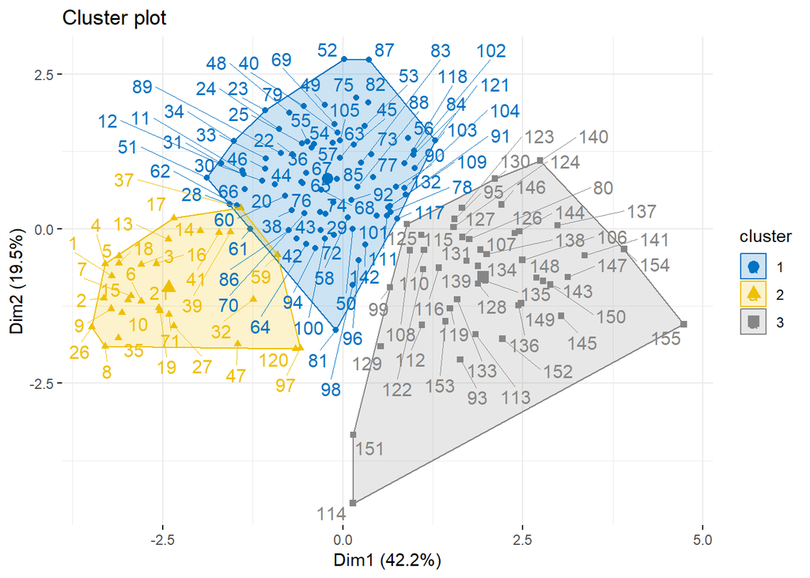

```r
fviz_cluster(happy3dup.k2,data=happy3dup.s,ellipse.type ="convex",palette="jco",repel = TRUE, ggtheme = theme_minimal())
```

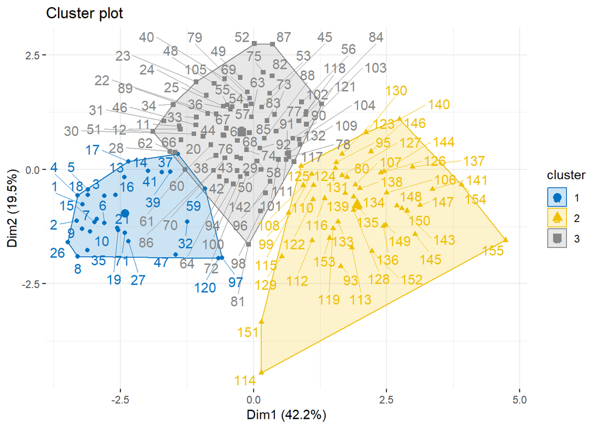

```r
fviz_cluster(happy3dup.k4,data=happy3dup.s,ellipse.type ="convex",palette="jco",repel = TRUE, ggtheme = theme_minimal())
```

M Clust

```r
happy3dup.mclust<-Mclust(happy3dup.s)
summary(happy3dup.mclust)
```

```
## ----------------------------------------------------
## Gaussian finite mixture model fitted by EM algorithm
## ----------------------------------------------------
##
## Mclust VVI (diagonal, varying volume and shape) model with 4 components:
##
##  log.likelihood   n df       BIC       ICL
##       -1196.501 155 59 -2690.564 -2708.876
##
## Clustering table:
##  1  2  3  4
## 17 24 70 44
```

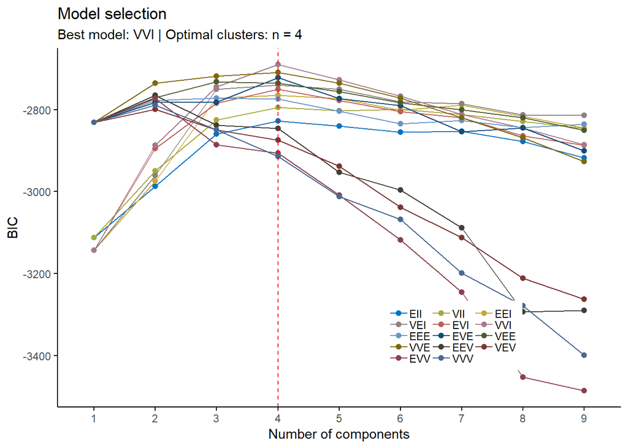

[figure not shown]

[figure not shown]

[output not shown]

```r
fviz_mclust(happy3dup.mclust,"BIC",palette="jco")
```

```r
data("happy2dup")
new_2016<-as.matrix(happy2dup)
new1_2016<-new_2016[sample(seq_len(nrow(new_2016))),]
dis_2016<-dist(new1_2016)
```

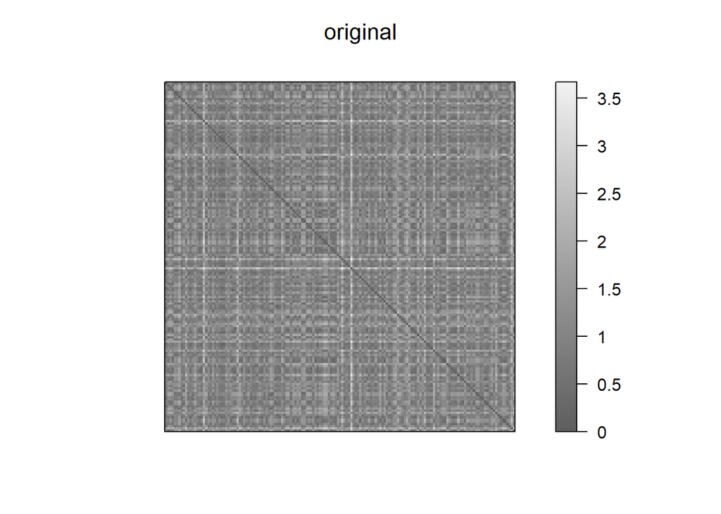

```r
ord_2016<-seriate(dis_2016,method="OLO")
pimage(dis_2016,main="original")
```

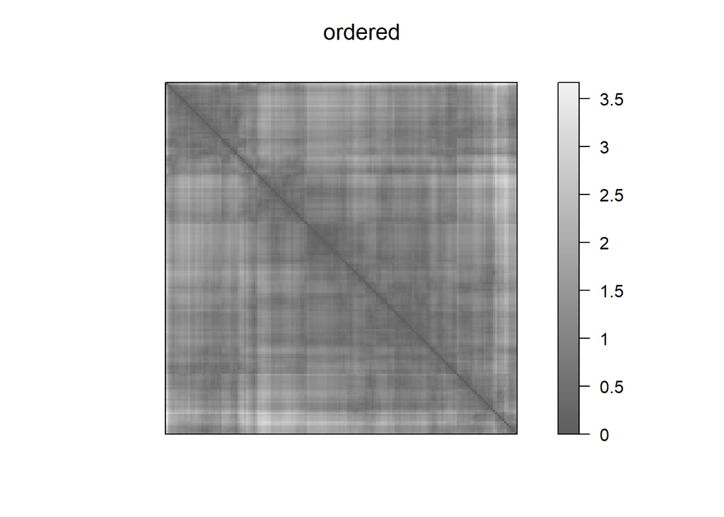

```r
pimage(dis_2016,ord_2016,main="ordered")
```

```r
get_order(ord_2016)
```

```
##   [1]  84 149 123  74 103  22 147  48 141  78   7 100  49  63 140  36  62
##  [18]  11  20  67  45  47  39  13 143  85   6   5 108 138 155  87 116 104
##  [35]  14  28 110 135  90 102 107  10  97 121  72  34  73  68 126  76 125
##  [52]  71  99  58 152  88 153  60  30  24  46  77  96  19  55  64   2  70
##  [69]  61 106  56 157 115  59  43  91 112  75   4  16  38  32 131 111   3
##  [86]  65 144 134  50 145 101  51  83  79 129  66  35  31  94  44 124 133
## [103]  40  26  86 118  27  98 113  17 119 154  69  12 151 130  52  21  89
## [120]  81 142   8  93  37  15 122  57 146   1  82  29 150  54  23  25 128
## [137]  41 148  42 136  95 120  92 139 137   9 105  80 132 117  33  18 156
## [154] 127  53 114 109
```

```r
data("happy3dup")
```

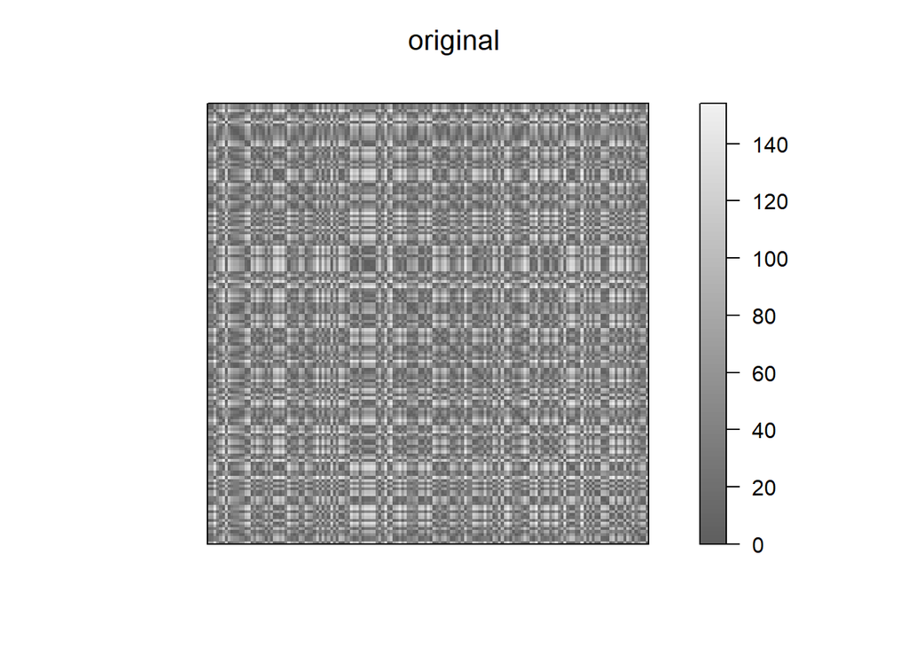

```r
new_2017<-as.matrix(happy3dup)
new1_2017<-new_2017[sample(seq_len(nrow(new_2017))),]
dis_2017<-dist(new1_2017)
ord_2017<-seriate(dis_2017,method="OLO")
pimage(dis_2017,main="original")
```

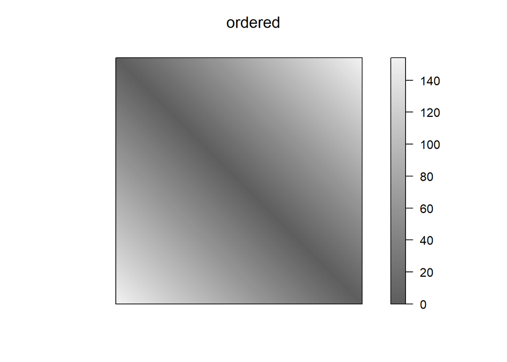

```r
pimage(dis_2017,ord_2017,main="ordered")
```

```r
get_order(ord_2017)
```

```
##   [1]  91  65  39 143   6 112  25 148 128  27  41 129  47  80 145   8  18
##  [18]  24 104 142  84 101 155 133  48 135  61 146 138  43  64  16  26 125
##  [35] 137 117  33  83 127 113  45  19 111   5  81 149  89 102   9  74  50
##  [52] 151 108  34  38 131  92  22  10  93  11  85  54  73 130  20  28  17
##  [69]  71 110 121  60  42  49 124  82   4  99  12  72  88  13  77 109 152
##  [86]  97  31 144  40  37  62 118 134 136   2  90  96  36  30   1  66  46
## [103] 147  69  32  23  87 141 100 107 122  21 115 154  79 153 150  67 103
## [120]  86  55  52  95  75 140  14 139  35 105  76 119   7 114  94  44  53
## [137]  57  70 120  56  15  59  29  58  78 123  98  51 126  63  68   3 106
## [154] 116 132
```

1. Norway tops the global happiness rankings for all three years 2015, 2016, and 2017 Everytime when the seration analysis is done, the outcome changes randomly. I don’t feel that Norway tops the global happiness for all the three years.
2. All top ten countries rank highly on all the main features found to support happiness I don’t think that the top 10 countries rank on the main features for happiness.
3. Happiness is both social and personal I don’t think that the happiness is based on both the social and personal. Few countries have good happiness rate for family but poor happiness rate for corruption, but still the countries ranks in the top.
4. Unemployment causes a major fall in happiness, and even for those in work the quality of work can cause major variations in happiness Even though there isn’t any variable to decide directly about the unemployment, the family’s happiness is comparatively less in many countries. The major reason for this could be unemployment and poverty.
5. China are no happier than most countries, though richer and longer longevity

Based on Cluster analysis, I believe that China is happier country.

6. Much of Africa is struggling

While doing the analysis, I found that most of the African countries fell into a single cluster and were grouped together. Morevover, the happiness rank is less for the African countries. Hence, I think that Africa is struggling.

7. Happiness has fallen in America

From the analysis, I understood that happiness is bit stable in America. It hasn’t risen or fallen much from 2015-2017.